# Part 2: Descriptive Statistics

307312 Applied Statistics — Masters Level

Download this part as PDF

## 307312 Applied Statistics — Masters Level

[figure not shown]

### What is Statistics?

Statistics is a mathematical science that includes methods for collecting, organizing, analyzing and visualizing data to extract useful information that can be used to make decisions.

Statistics help us solve problems, answer questions and make decisions based on data (Data Driven Decisions).

Statistics Helps to in Reduce Uncertainty.

Statistics is the science of making decisions under uncertainty (Savage, The Foundations of Statistics, 1954).

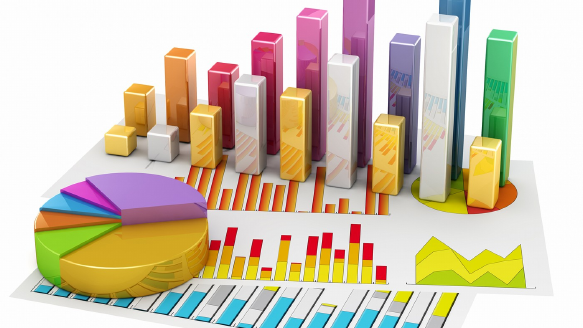

### Statistics Branches

Statistics is generally divided into two main branches:

1. Descriptive statistics.

Descriptive statistics refers to the summarizing and explaining data using numbers, tables and charts.

2- Inferential statistics.

Inferential statistics refers to drawing conclusions about a population based on a sample data.

A population refers to all members of a specified group (not necessarily people), whereas a sample is a subset of that population.

Population: the collection of all items we are interested in (people, things, plants, stars, trees…etc.), for the purpose of making our decision.

### Example of Useful Descriptive Statistics

1. Business Sales:

A store owner calculates the average daily sales to get a sense about his income.

The owner also computes the standard deviation of daily sales to understand the variability or consistency in income.

2. Classroom Grades:

A teacher calculates the average grade of a test to understand the overall performance of the class.

The teacher also determines the highest and lowest scores to understand the spread of the grades.

3. Survey Results:

After a customer satisfaction survey, a company finds that 70% of respondents are "satisfied" or "very satisfied."

The survey also indicates that the mode response to the question, "What's the most important feature?" is "product durability."

### Examples of Useful Inferential Statistics

1. Medicine:

A research group tests a new drug on 100 patients and finds that 60 of them show significant improvement.

Using inferential statistics, they can make conclusions about the drug's effectiveness on the entire population.

2. Agriculture:

A farmer tests a new fertilizer on a sample plot of land to see if it increases crop yield.

Inferential statistics can help predict the impact of using the fertilizer on all their plots.

3. Marketing:

A company launches a new ad campaign in a small geographic area.

They use inferential statistics to determine if rolling out the campaign nationwide would likely produce similar results.

### Statistical Process Life Cycle

1. 1Define Problem – Question
2. 2Collect Data
3. 3Prepare Data
4. 4Analyze Data
5. 5Find Insights
6. 6Make Decisions

The process returns to the question as needed.

## Types of Data & Levels of Measurements

### Categorical Data vs Numerical Data

1. **Qualitative** or **categorical** (non-numerical) data:

Consists of descriptive information, such as colors, tastes, textures, or any other characteristics that can be counted.

2. **Quantitative** or **numerical** data:

Includes data that can be measured and can be represented numerically, such as height, weight, or temperature.

### Types of data

Types of data

Categorical

Categorical data represents groups or categories.

**Examples:**

1. Car brands: Audi, BMW and Mercedes.
2. Answers to yes/no questions: yes and no

Numerical

Discrete

Continuous

Numerical data represents numbers. It is divided into two groups: discrete and continuous. Discrete data can be usually counted in a finite matter, while continuous is infinite and impossible to count.

**Examples:**  
Discrete: # children you want to have, SAT score  
Continuous: weight, height

### Levels of measurement

Levels of measurement

Qualitative

Nominal

Ordinal

There are two qualitative levels: nominal and ordinal. The nominal level represents categories that cannot be put in any order, while ordinal represents categories that can be ordered.

**Examples:**  
Nominal: four seasons (winter, spring, summer, autumn)  
Ordinal: rating your meal (disgusting, unappetizing, neutral, tasty, and delicious)

Quantitative

Interval

Ratio

There are two quantitative levels: interval and ratio. They both represent “numbers”, however, ratios have a true zero, while intervals don’t.

**Examples:**  
Interval: degrees Celsius and Fahrenheit  
Ratio: degrees Kelvin, length

### Why Types of Data and Levels of Measurements Matter?

Data Visualization: e.g. Categorical data might be best represented in a bar chart, while continuous data might be better suited for a histogram or scatter plot.

Data Transformation: e.g. Ordinal data might be converted into interval data under certain conditions, or continuous data might be categorized into ordinal data.

Data Quality: e.g. If you expect a variable to be discrete and find continuous values, this could indicate a data quality issue.

Interpretation of Results: e.g. If you have ordinal data, you can make statements about the order of values but not the difference between values.

Appropriate Analysis: e.g. Nominal data can be analyzed using a Chi-square test, while interval data can be analyzed using a t-test or ANOVA. Using the wrong test can lead to incorrect conclusions.

### Types of attributes and scales of measurement

| Scale of measurement | Type of attribute | Examples | Notes | Operations |
| --- | --- | --- | --- | --- |
| Nominal scale | Qualitative / Categorical | Gender, blood group, rhesus factor | Lowest level | A = B A ≠ B |
| Ordinal scale | Qualitative / Categorical | Grades, medical scores | Order is defined | A = B A ≠ B A < B A > B |
| Interval scale | Quantitative / Metric | Temperature in °C, intelligence quotient | Arbitrary zero, distance is defined | A = B A ≠ B A < B A > B d = A − B |
| Ratio scale | Quantitative / Metric | Temperature in Kelvin, body height | Highest level, natural zero, ratio is defined | A = B A ≠ B A < B A > B d = A − B r = A:B |

Figure 2.2: Types of attributes and scales of measurement.

Curtesy of: Introduction to statistical analysis with R, Matheus Khol

## Data collection and survey quality

Before summarizing data, ask how they were obtained.

- **Source:** Are suitable data already available, or must we collect them?
- **Selection:** Who or what should be included?
- **Measurement:** How will we obtain comparable, trustworthy answers?

By the end of this section, you should be able to select a collection approach, justify a survey mode and sampling method, and identify likely survey errors.

### Define what the study will measure

- **Target population:** The people or items to which the conclusion should apply; specify place and time.
- **Observational unit:** The person, transaction, branch or other item described by one observation.
- **Operational definition:** The exact rule used to measure a variable.

**Illustration:** “Service speed” could mean minutes from joining a queue to reaching a teller, or minutes from reaching the teller to completing a transaction. These are different variables.

State the rule and unit before collecting values. A clear variable name alone is insufficient.

### Primary and secondary data

**Primary data** are collected for the current study. A new customer survey can ask exactly what management needs, but requires time, access and resources.

**Secondary data** already exist for another purpose. Sales records, administrative records and published statistics may be faster to obtain, but their definitions, dates and coverage may not fit the question.

Check who collected the data, why, when, how and for whom. Internal business records can be secondary data for a new analysis; “secondary” does not mean “external.”

### Which collection approach fits the question?

| Approach | Useful when we need to know… | Main limitation |
| --- | --- | --- |
| Survey | What people report, prefer or believe | Reports may differ from actual behavior |
| Direct observation | What people do or how a process operates | Motives may remain unknown; privacy matters |
| Business or administrative records | What was recorded during operations | Missing events and changing definitions can mislead |
| Designed experiment | Whether an assigned intervention changes an outcome | Requires feasible, ethical treatment assignment and control |

Random assignment in a well-designed experiment supports causal comparisons. An association in routine observational data alone does not establish causation.

### Census, sample and sampling frame

A **census** attempts to collect data from every population unit. A **sample** includes a selected subset. Sampling can reduce cost and time; a census may be feasible for a small workforce.

The **sampling frame** identifies the units available for selection, such as a current employee list.

Distinguish **eligible population → frame → selected sample → respondents**. They need not contain the same people.

Inviting everyone is an attempted census; receiving replies from only some people does not eliminate nonresponse concerns.

Reference: [ABS: Census and sample](https://www.abs.gov.au/statistics/understanding-statistics/statistical-terms-and-concepts/census-and-sample).

### Probability sampling: who is selected?

Each population unit has a known, positive selection probability; probabilities need not be equal.

| Method | How it works | Useful setting and caution |
| --- | --- | --- |
| Simple random | Randomly select units from a complete frame | An up-to-date customer list; small groups may be missed by chance |
| Systematic | Choose a random start, then every *k*th unit | An ordered transaction list; avoid a repeating pattern aligned with *k* |
| Stratified | Divide into groups; randomly sample within every group | Comparing departments or regions; unequal sampling fractions need weights for overall estimates |
| Cluster | Randomly select groups, then study all or a sample of units within them | Dispersed branches or locations; similar units within clusters can reduce precision |

Strata contribute sampled units from **every** group; cluster sampling selects **some** groups. Neither design guarantees error-free results.

### Nonprobability samples: useful, with limits

- **Convenience:** Ask people who are easy to reach. Useful for testing a questionnaire quickly.
- **Voluntary response:** Invite anyone interested to reply. Useful for gathering suggestions; strongly motivated people may dominate.
- **Purposive:** Select people for relevant expertise. Useful for exploring a specialist problem.

These approaches can support exploration, but selection probabilities are unknown. A large response count alone does not justify population-wide percentages or a conventional probability-sampling margin of error.

An online questionnaire can use a probability sample or an opt-in sample. The communication channel does not determine the sampling design.

### Choosing a sampling method: a bank example

**Hypothetical planning example; no observed data.** A bank wants to describe service satisfaction among all its current adult retail customers.

| Method | What the bank would do | Why choose it? |
| --- | --- | --- |
| **Simple random** | Randomly draw customers from the complete customer list | Suitable for an overall estimate when precise comparisons between customer groups are not the main objective. Small groups can receive few selections by chance. |
| **Stratified random** | Divide customers into age groups—18–29, 30–59 and 60+—then randomly select customers within **every** group | Suitable when management needs to compare age groups. Their service needs or digital experiences may differ, and a small group could otherwise have too few responses for a useful comparison. |
| **Systematic** | Choose a random starting position among the first 20 names, then select every 20th customer | Convenient for working through a long list. Check that the ordering has no repeating pattern aligned with the selection interval. |
| **Cluster** | Randomly select some branches, then randomly sample customers assigned to those branches | Suitable when interviews require branch visits: fewer locations reduce travel. Customers within a branch may be similar, so precision can be lower than with a similarly sized simple random sample. |
| **Nonprobability** | Ask available branch visitors to test a draft questionnaire, or deliberately interview customers with relevant experience | Suitable for piloting questions or exploring a problem. These people can provide useful feedback, but their satisfaction percentage should not be treated as representative of all customers. |

### Customer segments, strata and clusters

**Customer segments** are groups defined by a characteristic relevant to the business question, such as age, region or account type. For stratified sampling, use groups that do not overlap and together cover the target population.

In the bank example, the age groups are **strata**. Sampling within every age group ensures each enters the selected sample; this helps management study each group’s experience. It does not mean surveying every customer, taking equal numbers from every group, or guaranteeing that everyone selected responds.

If a small group is deliberately sampled more heavily, use appropriate **weights** when combining results: its sample responses should not count as though that group makes up an equally large share of all customers.

The branches in the cluster example are **clusters**. Assign each customer to one designated branch for selection, so customers using several branches are not counted repeatedly. Visit only the randomly selected branches; the purpose is to reduce collection cost, rather than obtain a separate estimate for every branch.

**Remember:** stratified sampling selects customers from **every group**; cluster sampling selects **some groups**, then studies customers within them.

### Survey modes: online and telephone

| Mode | Why and where we might use it | What to watch |
| --- | --- | --- |
| Online / email invitation | Fast repeated feedback from customers with reliable digital access; automated routing and visual response options | Digital exclusion, ignored invitations and self-selection if a link is openly posted |
| Telephone interview | Short interviews when telephone contact details are available; an interviewer can clarify instructions | Unanswered calls, interviewer effects and difficulty presenting long visual lists |

For either mode, specify how invitees are selected. An accessible survey is of little use if the contact list omits the population of interest.

Reference: [AAPOR: Survey research practices](https://aapor.org/standards-and-ethics/best-practices/).

### Survey modes: face-to-face and paper

| Mode | Why and where we might use it | What to watch |
| --- | --- | --- |
| Face-to-face interview | Complex questions, physical demonstrations or populations difficult to reach remotely; interviewers can assist | Travel and staffing cost, interviewer influence and privacy during the interview |
| Paper questionnaire | Respondents with limited internet access, or settings where paper is practical; postal return permits private completion | Slow returns, manual entry errors and reading or language barriers |

An interviewer may improve comprehension but also increase socially desirable answers. Private self-completion can help with sensitive questions when respondents can use it comfortably.

References: [AAPOR](https://aapor.org/standards-and-ethics/best-practices/); [Pew: Mode effects](https://www.pewresearch.org/short-reads/2019/02/07/phone-vs-online-surveys-why-do-respondents-answers-sometimes-differ-by-mode/).

### Choosing a mode and combining modes

Choose using **population access, question complexity, sensitivity, cost and available time**.

**Illustrative decision:** A bank studying all retail customers could invite a selected sample online, then offer telephone or paper completion to people who cannot respond online.

Mixed modes can improve access, but require consistent meaning and response options, controlled follow-up, and checks for duplicate submissions.

Changing mode can change answers even if opinions have not changed. Record the mode and examine comparability when tracking trends.

References: [AAPOR](https://aapor.org/standards-and-ethics/best-practices/); [Pew: Mode effects](https://www.pewresearch.org/short-reads/2019/02/07/phone-vs-online-surveys-why-do-respondents-answers-sometimes-differ-by-mode/).

### Questionnaire design and a small pilot

| Problem | Better approach |
| --- | --- |
| “How excellent was our fast, friendly service?” | Use neutral wording; ask about speed and friendliness separately |
| “Do you shop here regularly?” | Specify a recall period: “How many purchases did you make here in the past seven days?” |
| Overlapping numerical categories | Use non-overlapping, complete ranges; include zero where relevant |

Offer “not applicable” or “don’t know” when meaningful. Do not force an opinion that the respondent does not have.

**Pretest** interpretation with potential respondents. **Pilot** the full process—invitation, routing, completion, recording and export—before launching it widely.

Reference: [Pew: Writing survey questions](https://www.pewresearch.org/writing-survey-questions/).

### Four sources of survey error

| Error | Diagnostic question |
| --- | --- |
| Coverage | Could the intended population enter the sampling frame correctly? |
| Nonresponse | Did selected people provide the requested answers? |
| Sampling | How much might the estimate vary across repeated probability samples? |
| Measurement | Do recorded answers measure the intended characteristic? |

Coverage, nonresponse and measurement errors are **non-sampling errors**. They can also affect a census. Processing mistakes, such as coding errors, are another source of non-sampling error.

Reference: [ABS: Types of error](https://www.abs.gov.au/statistics/understanding-statistics/statistical-terms-and-concepts/types-error).

### Coverage error: who cannot enter?

The frame may omit eligible units, include ineligible units or list units more than once.

**Illustration:** A bank wants all customers’ views, but selects only from its mobile-app user list. Customers who do not use the app cannot be selected.

**Improve it:** Compare the frame with the target population; update contact information, remove duplicates and add missing groups through suitable sources.

Sending more invitations from the same incomplete frame does not correct the omission.

### Nonresponse error: who does not answer?

**Unit nonresponse:** No questionnaire is returned. **Item nonresponse:** Some answers are missing.

**Illustration:** Selected dissatisfied customers may ignore a bank’s invitation. The resulting satisfaction estimate could be too high if respondents and nonrespondents differ on satisfaction.

**Improve it:** Use clear invitations, reasonable length, reminders and alternative modes. Compare available characteristics of respondents and nonrespondents.

A response rate alone does not establish the size or direction of bias. Weighting may help with observed differences; it cannot guarantee that all bias is removed.

### Sampling error: variation without a mistake

Repeated probability samples can give different estimates even when the same correct procedure is followed.

Larger samples usually reduce sampling variability under comparable designs. They do not automatically remove systematic coverage, nonresponse or measurement problems.

A confidence interval or margin of error describes specified sampling uncertainty under its assumptions; it does not normally include every source of survey error.

**Precision** concerns variability. **Bias** concerns systematic deviation. An estimate can be precise and biased.

### Measurement error: what answer was obtained?

Recorded values may differ from the characteristic we intended to measure because of unclear wording, faulty recall, interviewer influence or a faulty instrument.

**Illustration:** A customer reports an approximate queue time from memory; the study needs elapsed time measured by timestamps. These measurements may differ systematically.

**Improve it:** Define units and recall periods, use neutral wording, check translations, train interviewers and pretest questions. Use an appropriate direct measure when available.

Correctly entering an answer does not prove that the underlying measurement is valid.

### Before analysis: quality checks and responsible collection

- Explain purpose, voluntary participation and data use; collect only necessary identifiers and protect access.
- Promise anonymity only when responses cannot be linked to individuals; otherwise explain confidentiality accurately.
- Check duplicates, impossible values, units, missing-value codes and routing errors. Preserve raw records and document changes.
- Report the population, frame, selection method, modes, collection dates, achieved responses and known limitations.

Do not replace a missing answer with zero unless zero is its true meaning. Cleaning cannot recover people excluded by the study design.

Reference: [AAPOR: Survey research practices](https://aapor.org/standards-and-ethics/best-practices/).

### Discussion: design and diagnose a customer survey

**Hypothetical scenario; no observed data:** A bank wants to describe service satisfaction among all current retail customers. It posts a questionnaire inside its app. The first question asks, “How satisfied are you with our excellent service?”

1. Define the population, observational unit and satisfaction measure.
2. Is the app a survey mode, a sampling frame, or both in this design? Who might be absent?
3. Propose a selection method and a response mode; explain why each fits.
4. Identify potential coverage, nonresponse and measurement problems. Could a larger response count fix them?
5. Rewrite the opening question and describe one pilot check.

After these design checks, we can organize the collected data using tables, charts and numerical summaries.

### References for the added material

- Chapter 1 summary and teaching guide, *Defining and Collecting Data*, supplied in the earlier course. Used as a planning reference; textbook page claims and publisher datasets were not independently verified.
- [Australian Bureau of Statistics: Census and sample](https://www.abs.gov.au/statistics/understanding-statistics/statistical-terms-and-concepts/census-and-sample).
- [Australian Bureau of Statistics: Types of error](https://www.abs.gov.au/statistics/understanding-statistics/statistical-terms-and-concepts/types-error).
- [AAPOR: Best practices for survey research](https://aapor.org/standards-and-ethics/best-practices/).
- [Pew Research Center: Writing survey questions](https://www.pewresearch.org/writing-survey-questions/).
- [Pew Research Center: Phone versus online mode effects](https://www.pewresearch.org/short-reads/2019/02/07/phone-vs-online-surveys-why-do-respondents-answers-sometimes-differ-by-mode/).

Added course explanations and hypothetical illustrations, 3 November 2026. No original slide text or case observations were replaced.

## Descriptive Statistics Tools

### Statistical Tools Used in Descriptive Statistics

Tables (Data Tables, Frequency Distribution Tables).

Visualization & Charts.

Numerical Measures (Measures of Central Location, Dispersion, Shape, Position, Association).

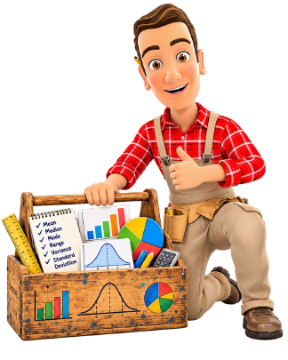

### Tables in Descriptive Statistics

Tables organize and display data in a structured format.

They are essential for summarizing large data sets efficiently.

Types of Tables in Statistics

Frequency Distribution Tables: Show how often each value in a set of data occurs.

Summary Tables: Provide key statistics like mean, median, mode, range, etc., at a glance.

Contingency Tables/Cross-tabulation: Display the multivariate frequency distribution for categorical data.

In the next section, we present tables examples using students dataset.

### Introducing Students Dataset

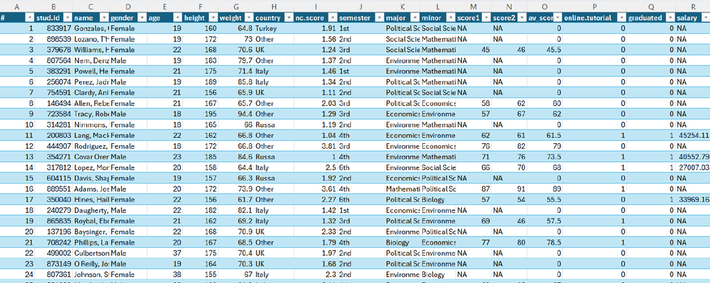

#### R equivalent (added)

```r
# read.csv() imports the supplied CSV; stringsAsFactors=FALSE keeps category labels as text.
# head() previews six rows; height is in cm, weight in kg, and age in years.
students <- read.csv("data/307102/students.csv", stringsAsFactors = FALSE)
head(students)
```

```
  gender age height weight country                  major
1 Female  19    160   64.8  Turkey      Political Science
2 Female  19    172   73.0   Other        Social Sciences
3 Female  22    168   70.6      UK        Social Sciences
4   Male  19    183   79.7   Other Environmental Sciences
5 Female  21    175   71.4   Italy Environmental Sciences
6   Male  19    189   85.8   Italy      Political Science
```

### Frequency Distribution Tables

Used to show the distribution of data across different categories or intervals.

Frequency Types:

Absolute Frequency: The actual count of occurrences for each category.

Relative Frequency: The proportion of the total count represented by each category, often expressed as a percentage.

Cumulative Frequency: A running total of frequencies through the categories, showing the number of observations up to a certain category.

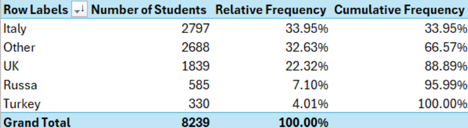

**Frequency of Students by Country**

#### R equivalent (added)

```r
# table() counts students in each country category; prop.table() divides by all counted students.
# Multiplying by 100 gives percentages; cumsum() is meaningful only when categories have an order.
country_counts <- table(students$country)
country_counts
```

```
 Italy  Other  Russa Turkey     UK
  2797   2688    585    330   1839
```

```r
100 * prop.table(country_counts)
```

```
    Italy     Other     Russa    Turkey        UK
33.948295 32.625319  7.100376  4.005340 22.320670
```

### Converting Numerical Values into Categorical

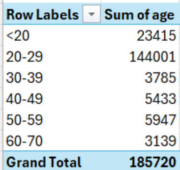

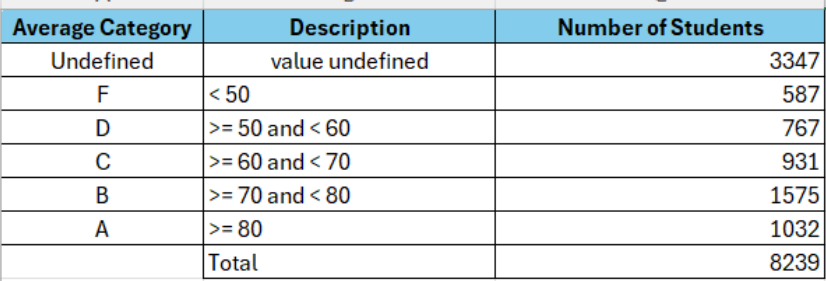

**Converting average into average groups**

**Converting age into age groups**

#### R equivalent (added)

```r
# cut() converts ages in years into intervals; right=FALSE includes the lower boundary, not the upper.
# table() counts each interval; these explicitly chosen bands are an added R illustration.
age_groups <- cut(students$age, breaks = c(0, 20, 25, 30, Inf), right = FALSE)
table(age_groups)
```

```
age_groups
  [0,20)  [20,25)  [25,30) [30,Inf)
    1246     6167      433      393
```

### Cross-tabulation or Contingency Tables

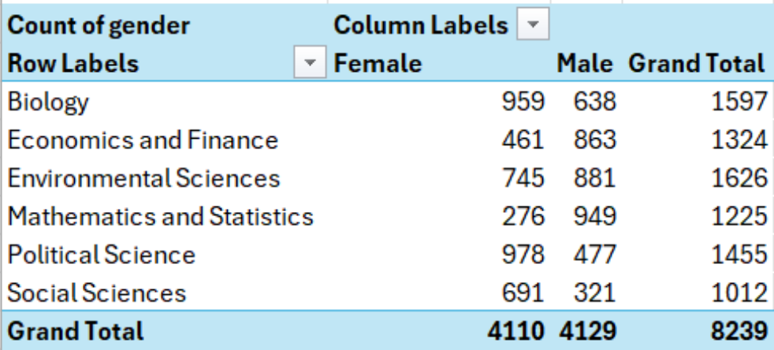

Used to show the **relationship between two categorical variables**.

Major by Gender in our example.

#### R equivalent (added)

```r
# xtabs() counts combinations: the formula ~ major + gender creates a two-way frequency table.
# addmargins() adds row and column totals without changing the underlying counts.
major_gender <- xtabs(~ major + gender, data = students)
addmargins(major_gender)
```

```
                            gender
major                        Female Male  Sum
  Biology                       959  638 1597
  Economics and Finance         461  863 1324
  Environmental Sciences        745  881 1626
  Mathematics and Statistics    276  949 1225
  Political Science             978  477 1455
  Social Sciences               691  321 1012
  Sum                          4110 4129 8239
```

## Data Visualization

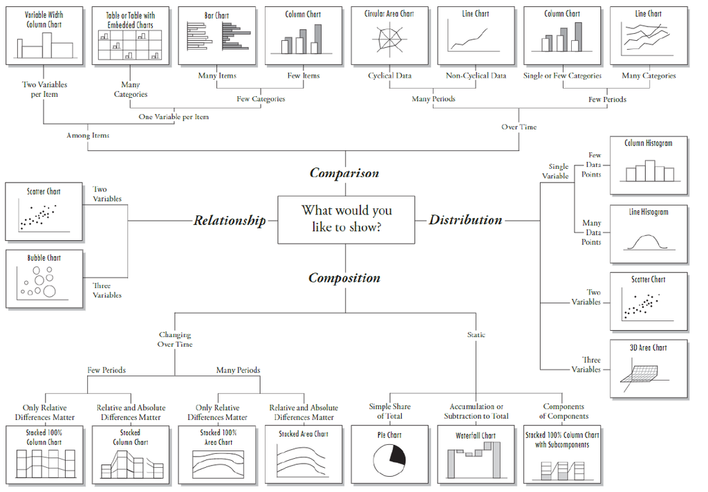

### Visualizing Qualitative Data

Bar Chart, Pie Chart, Pareto Plots, Side by Side Bars Chart

### Bar Charts

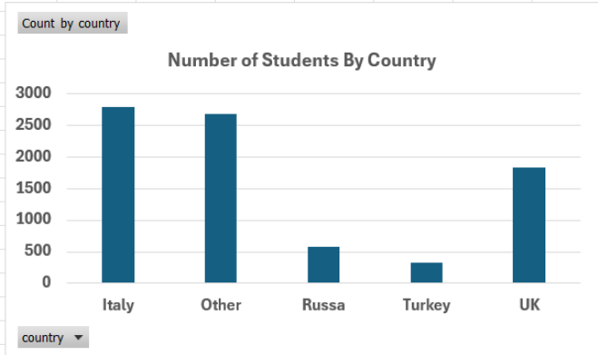

A bar chart is a type of chart that presents data in rectangular bars with lengths proportional to the values they represent.

Bar charts are commonly used to compare the magnitudes of different categories or groups of data.

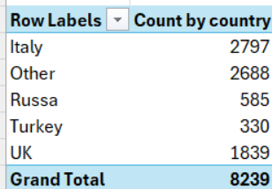

We need to construct a frequency table first.

#### R equivalent (added)

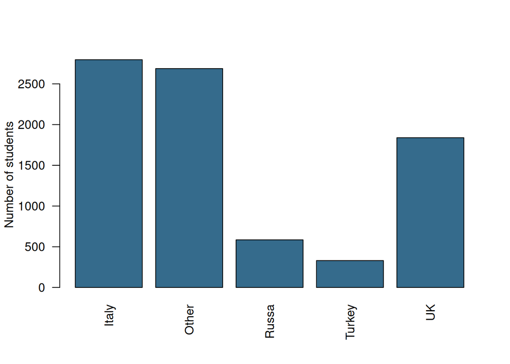

```r
# barplot() draws a bar for each category count supplied by table().
# las=2 rotates country labels; ylab states that bar heights are numbers of students.
barplot(table(students$country), las = 2, col = "#356B8C", ylab = "Number of students")
```

### Pie Chart: Visualizing Proportions

A pie chart is a circular chart that is divided into segments to represent numerical proportions or percentages.

Each segment of the pie chart represents a different category or group, and the size of each segment is proportional to the value or percentage it represents.

Pie charts are commonly used to display data that can be divided into categories, such as market share, demographic distributions, or survey results.

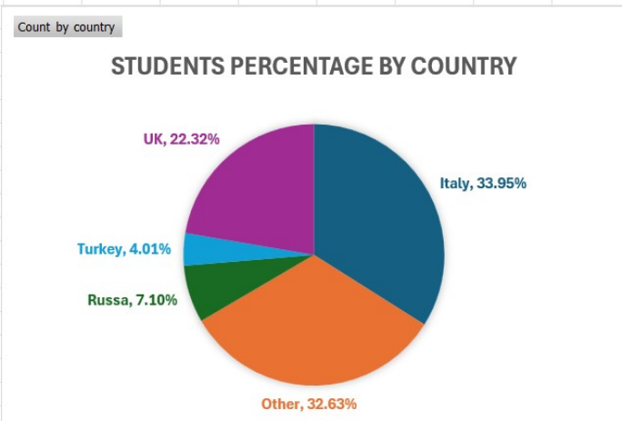

#### R equivalent (added)

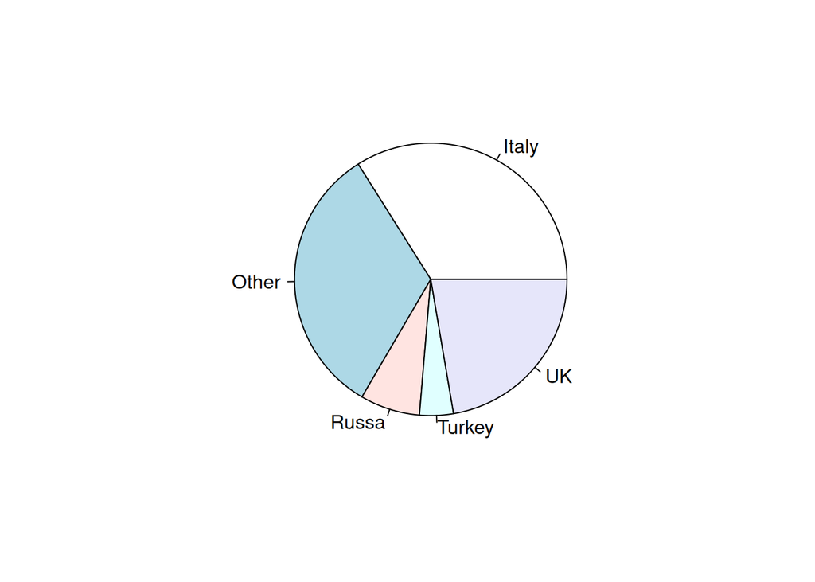

```r
# pie() divides the circle according to the country counts computed by table().
# The denominator is all students with a recorded country category, including Other.
pie(table(students$country))
```

### Pareto Charts: Two Graphs in a Single Chart

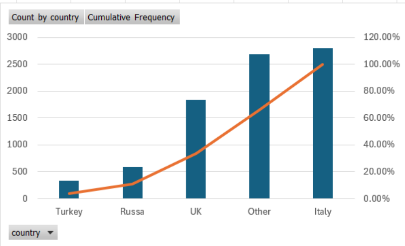

A Pareto chart is a type of chart that combines a bar graph with a line graph (Combo Chart).

It is used to display the relative frequency or size of different categories or groups, and to identify the most important factors affecting a particular outcome or result.

### Side by Side Bar Charts: : Visualizing Two Variables

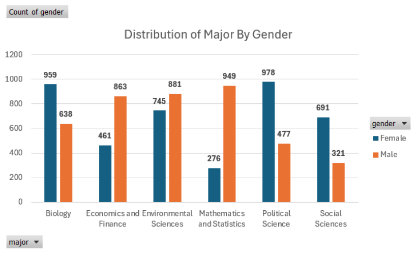

A side-by-side chart is used to compare two or more variables or categories.

The chart displays the data side-by-side in separate columns or bars, making it easy to compare the values of each variable or category.

Side-by-side chart allows viewers to quickly and easily compare the values of different variables and identify patterns or trends in the data.

#### R equivalent (added)

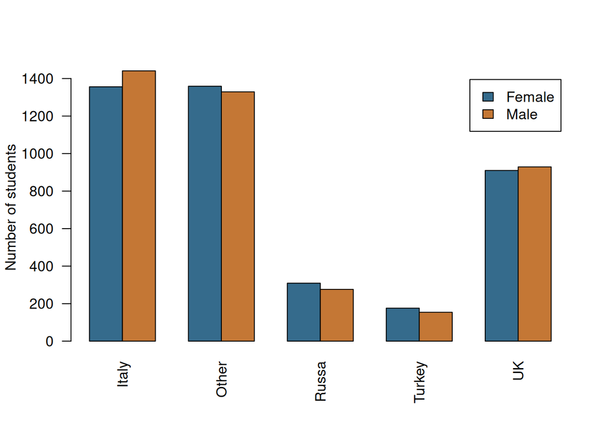

```r
# table() cross-classifies gender and country; barplot(beside=TRUE) places gender bars side by side.
# legend.text=TRUE labels the groups; counts, rather than percentages, determine bar heights.
barplot(table(students$gender, students$country), beside = TRUE, legend.text = TRUE,
        col = c("#356B8C", "#C47735"), ylab = "Number of students", las = 2)
```

### Visualizing Quantitative Data, Frequency Distributions and Histograms

### Histograms

Histograms provide a way to visualize the distribution of a numeric variable.

Histograms group numeric responses into bins and display the frequency of responses in each.

The x-axis of a histogram reflects the range of values of a numeric variable, while the y-axis can reflect either the frequencies (counts) or relative frequencies.

#### R equivalent (added)

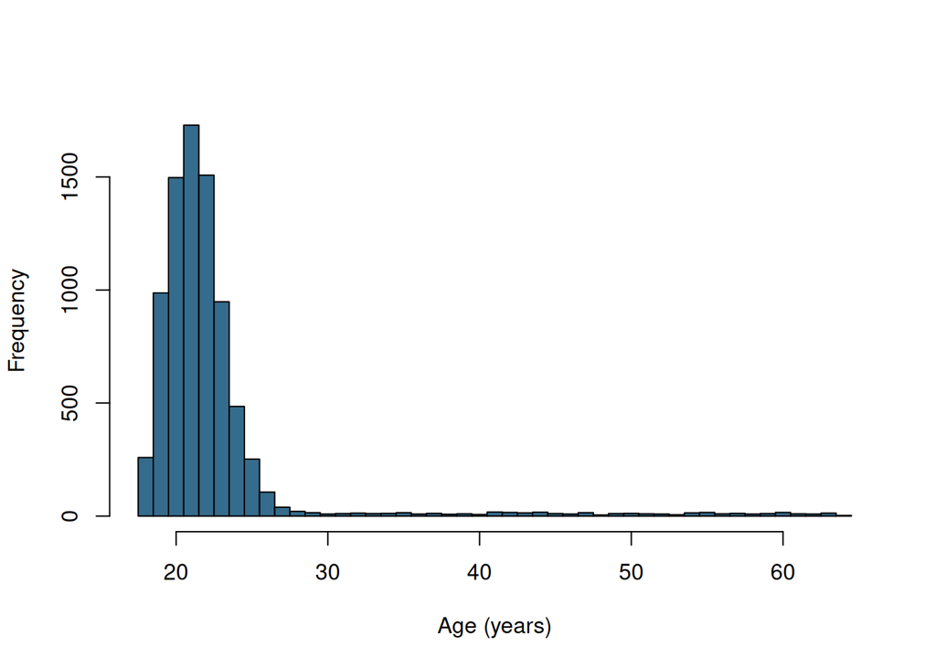

```r
# hist() groups ages into bins; breaks specifies yearly boundaries at half-year positions.
# freq=TRUE displays counts rather than probability density; recorded ages are measured in years.
hist(students$age, breaks = seq(min(students$age) - 0.5, max(students$age) + 0.5, by = 1),
     freq = TRUE, col = "#356B8C", main = "", xlab = "Age (years)")
```

### Histograms

Histograms tell us the following about our data:

Shape – what is the shape of the distribution?

Center – what is an “average” value?

Spread – how far away from the center do values tend to fall?

Unique features – are there any outliers?

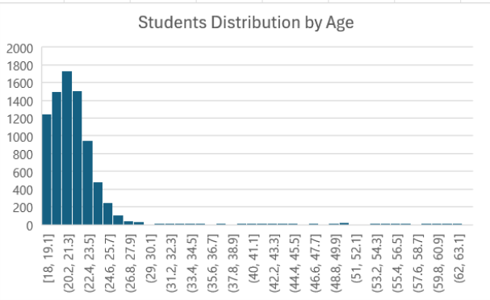

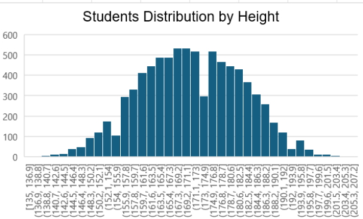

### Number of Modes

The first distinguishing feature apparent in a histogram is the number of modes, or, in the distribution.

A unimodal distribution only has one peak in the distribution, a bimodal distribution has two peaks, and a multimodal distribution has three or more peaks.

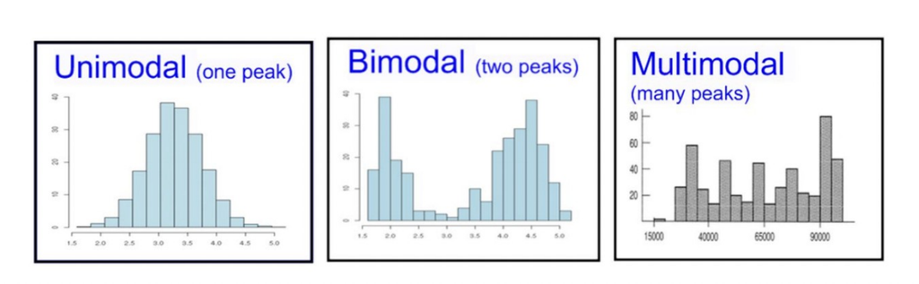

### Skewness

Histograms can show us if the data is skewed or symmetric.

Symmetric data should look nearly identical if folded in half at the center point of the distribution.

Skewed data indicates that there is a large portion of the data collected on one side of the chart and only a small portion on the other side.

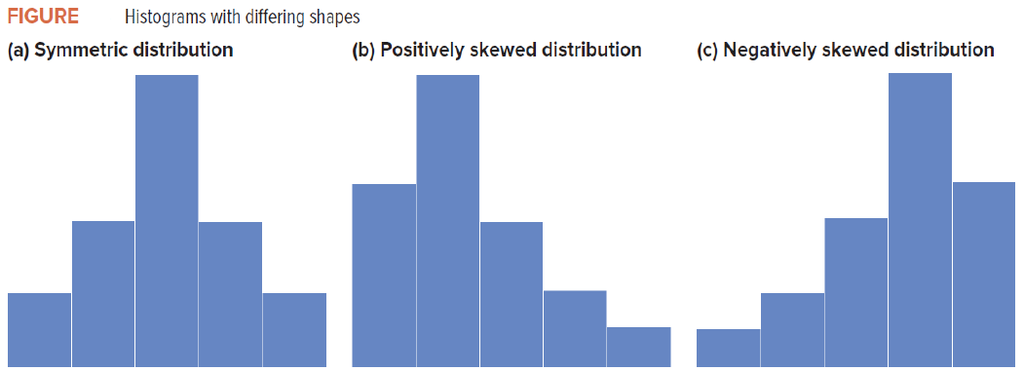

### Outliers

Outliers are responses that fall well away from the rest of the values.

Histograms can be useful in identifying outliers in our data.

Defining an observation as an outlier is subjective and should lead to an investigation of that value (not an automatic removal from the dataset).

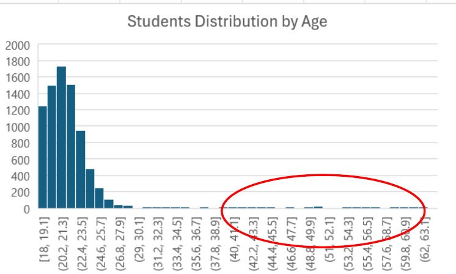

### Scotter Plots

Scatter plots can be used to examine of there is a relation between two variables.

Consider for instance, how:

Incomes vary with education.

Sales vary with advertising expenditures.

Stock prices vary with corporate profits.

Crop yields vary with the use of fertilizer.

Cholesterol levels vary with dietary intake.

Price varies with reliability.

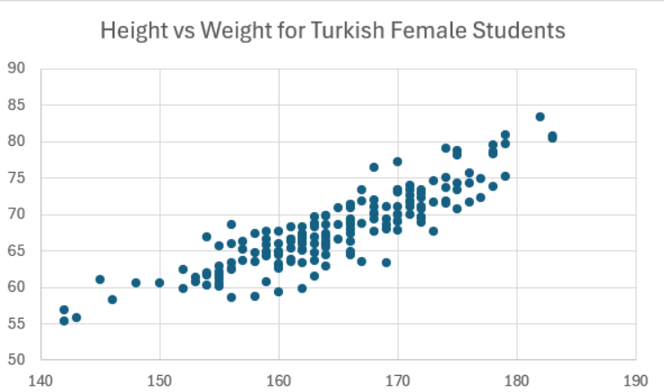

#### R equivalent (added)

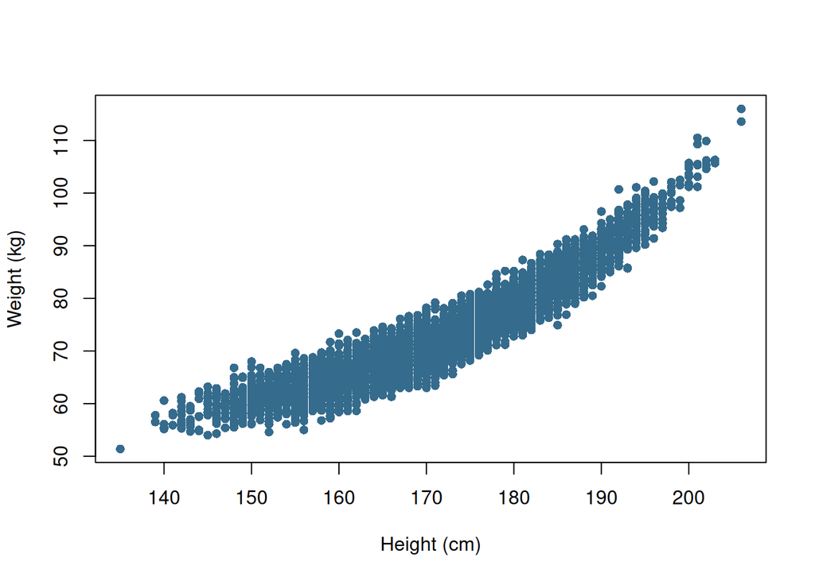

```r
# plot(x,y) makes a scatterplot, with height on the horizontal axis and weight on the vertical.
# pch=16 uses filled points; no fitted line or causal relationship is assumed.
plot(students$height, students$weight, pch = 16, col = "#356B8C",
     xlab = "Height (cm)", ylab = "Weight (kg)")
```

### Relations between Two Variables

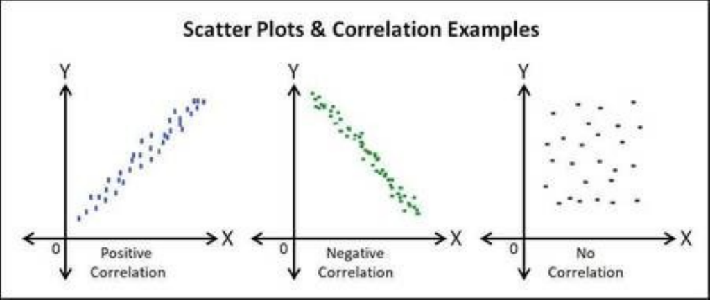

## Numerical Measures in Descriptive Statistics

### Numerical Measures in Descriptive Statistics

Numerical measures in descriptive statistics are used to summarize and describe the main features of a dataset through numbers.

These measures provide insights into the distribution, central tendency, dispersion, and shape of the data.

Understanding these measures helps in interpreting the data more effectively.

Examples

Rates in a Society (unemployment rate, crime rate, divorce rate).

Average Income, Maximum age, Minimum score…etc.

### Measures of Central Location

Mean, Median and Mode

### The Mean

The **Arithmetic Mean** is the primary measure of central location.

Generally, we refer to the arithmetic mean as simply the **Mean** or the **Average**.

In order to calculate the mean of a data set, we simply add up the observations and divide by the number of observations in the population or sample.

**However, the mean is sensitive to** **Outliers****. Consider the following sample dataset:**

**Data = ($1.00, $2.00, $3.00, $3.00, $3.00, $1.00, $100.00)**

**Most of the data values are around $3, yet their average is** **$16.14**

### The Median

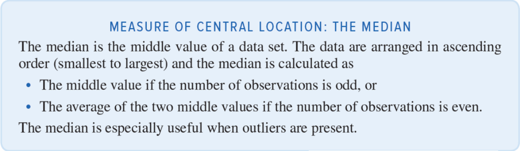

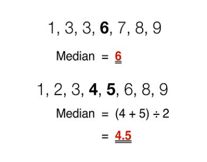

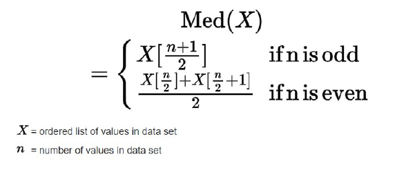

### The Mode

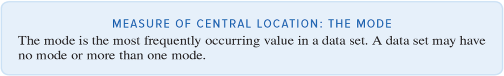

### Excel Functions for Measuring Central Location

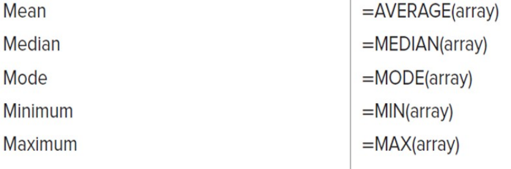

### Practical Exercise

Use the students.xlsx file:

Compare the Mean, Median for the “age” column for “Italy” and “Russa”.

Find the Mode “age” column for “UK”.

Note: In Excel you can filter out rows by converting a Range to a Table and using the filtering list in each header of a column.

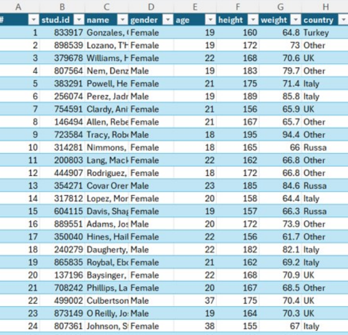

#### R equivalent (added)

```r
# mean() and median() summarize ages; table() counts each recorded age to identify every tied mode.
# names() returns the ages whose counts equal max(), the greatest frequency.
mean(students$age)
```

```
[1] 22.54157
```

```r
median(students$age)
```

```
[1] 21
```

```r
age_counts <- table(students$age)
names(age_counts)[age_counts == max(age_counts)]
```

```
[1] "21"
```